# Google Play Store Apps

## by Abdelrhman Khairy Werby

```python
# import all packages and set plots to be embedded inline
import numpy as np
import pandas as pd
import matplotlib.pyplot as plt
import seaborn as sb

%matplotlib inline
```

> Load in your dataset and describe its properties through the questions below. Try and motivate your exploration goals through this section.

```python
# load the dataset
df = pd.read_csv('Google-Playstore.csv')
# show first rows
df.head()
```

|  | App Name | App Id | Category | Rating | Rating Count | Installs | Minimum Installs | Maximum Installs | Free | Price | ... | Developer Id | Developer Website | Developer Email | Released | Last Updated | Content Rating | Privacy Policy | Ad Supported | In App Purchases | Editors Choice |
| --- | --- | --- | --- | --- | --- | --- | --- | --- | --- | --- | --- | --- | --- | --- | --- | --- | --- | --- | --- | --- | --- |
| 0 | HTTrack Website Copier | com.httrack.android | Communication | 3.6 | 2848.0 | 100,000+ | 100000.0 | 351560 | True | 0.0 | ... | Xavier Roche | http://www.httrack.com/ | roche+android@httrack.com | Aug 12, 2013 | May 20, 2017 | Everyone | http://android.httrack.com/privacy-policy.html | False | False | False |
| 1 | World War 2: Offline Strategy | com.skizze.wwii | Strategy | 4.3 | 17297.0 | 1,000,000+ | 1000000.0 | 2161778 | True | 0.0 | ... | Skizze Games | http://stereo7.com/ | Skizze.Games@gmail.com | Jul 19, 2018 | Nov 26, 2020 | Everyone 10+ | https://www.iubenda.com/privacy-policy/8032781 | True | True | False |
| 2 | WPSApp | com.themausoft.wpsapp | Tools | 4.2 | 488639.0 | 50,000,000+ | 50000000.0 | 79304739 | True | 0.0 | ... | TheMauSoft | http://www.themausoft.com | wpsapp.app@gmail.com | Mar 7, 2016 | Oct 21, 2020 | Everyone | https://sites.google.com/view/wpsapppolicy/main | True | False | False |
| 3 | OfficeSuite - Office, PDF, Word, Excel, PowerP... | com.mobisystems.office | Business | 4.2 | 1224420.0 | 100,000,000+ | 100000000.0 | 163660067 | True | 0.0 | ... | MobiSystems | http://www.mobisystems.com | support-officesuite-android@mobisystems.com | Dec 22, 2011 | Nov 23, 2020 | Everyone | http://www.mobisystems.com/mobile/privacy-poli... | True | True | False |
| 4 | Loud Player Free | com.arthelion.loudplayer | Music & Audio | 4.2 | 665.0 | 50,000+ | 50000.0 | 73463 | True | 0.0 | ... | Arthelion92 | http://www.arthelion.com | arthelion92@gmail.com | Sep 24, 2016 | Nov 22, 2020 | Everyone | http://www.arthelion.com/index.php/fr/android-... | False | False | False |

5 rows × 23 columns

## Data cleaning

```python
# check the missing value and colmuns type
df.info()
```

```
<class 'pandas.core.frame.DataFrame'>
RangeIndex: 1118136 entries, 0 to 1118135
Data columns (total 23 columns):
App Name             1118135 non-null object
App Id               1118136 non-null object
Category             1118133 non-null object
Rating               1111286 non-null float64
Rating Count         1111286 non-null float64
Installs             1117975 non-null object
Minimum Installs     1117975 non-null float64
Maximum Installs     1118136 non-null int64
Free                 1118136 non-null bool
Price                1118136 non-null float64
Currency             1117975 non-null object
Size                 1118136 non-null object
Minimum Android      1116123 non-null object
Developer Id         1118134 non-null object
Developer Website    703770 non-null object
Developer Email      1118114 non-null object
Released             1110406 non-null object
Last Updated         1118136 non-null object
Content Rating       1118136 non-null object
Privacy Policy       964612 non-null object
Ad Supported         1118136 non-null bool
In App Purchases     1118136 non-null bool
Editors Choice       1118136 non-null bool
dtypes: bool(4), float64(4), int64(1), object(14)
memory usage: 166.3+ MB
```

### Drop nan value

```python
# replace any 'Varies with device' value in Size colmuns with nan value
df.Size = df.Size.replace('Varies with device', np.nan)
# remove all row with nan value
df.dropna(inplace=True)
# remove all duplicates row
df.drop_duplicates(inplace=True)
```

### Remove space in colmuns name

```python
# Remove space in colmuns name
df.columns = df.columns.str.replace(' ', '')
```

### Convert string data types to float in [Size, Installs]

```python
# in size colmuns relplace 'K' with 1000
df.Size = df.Size.str.replace('k','e+3')
# in size colmuns relplace 'M' with 1000,000
df.Size = df.Size.str.replace('M','e+6')
# in size colmuns relplace 'G' with 1000,000,000
df.Size = df.Size.str.replace('G','e+9')
# in size colmuns remove the ','
df.Size = df.Size.str.replace(',', '')
# convert the Size colmuns from string to float
df.Size = df.Size.astype(float)
# Divide the Size by 1024 to convert from Bytes to KB
df.Size = df.Size * 1e-6
df.Size.head()
```

```
0     2.7
1    86.0
2     5.8
3    59.0
4    29.0
Name: Size, dtype: float64
```

```python
# remove '+'
df.Installs = df.Installs.apply(lambda x: x.strip('+'))
# remove the ','
df.Installs = df.Installs.str.replace(',','')
# convert to float
df.Installs = df.Installs.astype(float)
df.Installs.head()
```

```
0       100000.0
1      1000000.0
2     50000000.0
3    100000000.0
4        50000.0
Name: Installs, dtype: float64
```

```python
df.describe()
```

|  | Rating | RatingCount | Installs | MinimumInstalls | MaximumInstalls | Price | Size |
| --- | --- | --- | --- | --- | --- | --- | --- |
| count | 598935.000000 | 5.989350e+05 | 5.989350e+05 | 5.989350e+05 | 5.989350e+05 | 598935.000000 | 598935.000000 |
| mean | 2.635863 | 5.896341e+03 | 2.722812e+05 | 2.722812e+05 | 4.791016e+05 | 0.208769 | 20.853932 |
| std | 2.017508 | 1.808903e+05 | 5.558161e+06 | 5.558161e+06 | 8.487615e+06 | 3.370573 | 23.901318 |
| min | 0.000000 | 0.000000e+00 | 0.000000e+00 | 0.000000e+00 | 0.000000e+00 | 0.000000 | 0.005800 |
| 25% | 0.000000 | 0.000000e+00 | 1.000000e+02 | 1.000000e+02 | 2.060000e+02 | 0.000000 | 5.600000 |
| 50% | 3.700000 | 1.500000e+01 | 1.000000e+03 | 1.000000e+03 | 2.411000e+03 | 0.000000 | 12.000000 |
| 75% | 4.300000 | 1.620000e+02 | 1.000000e+04 | 1.000000e+04 | 2.924500e+04 | 0.000000 | 27.000000 |
| max | 5.000000 | 6.850709e+07 | 1.000000e+09 | 1.000000e+09 | 1.597811e+09 | 400.000000 | 1000.000000 |

```python
# show the head after the cleaning phase
df.head()
```

|  | AppName | AppId | Category | Rating | RatingCount | Installs | MinimumInstalls | MaximumInstalls | Free | Price | ... | DeveloperId | DeveloperWebsite | DeveloperEmail | Released | LastUpdated | ContentRating | PrivacyPolicy | AdSupported | InAppPurchases | EditorsChoice |
| --- | --- | --- | --- | --- | --- | --- | --- | --- | --- | --- | --- | --- | --- | --- | --- | --- | --- | --- | --- | --- | --- |
| 0 | HTTrack Website Copier | com.httrack.android | Communication | 3.6 | 2848.0 | 100000.0 | 100000.0 | 351560 | True | 0.0 | ... | Xavier Roche | http://www.httrack.com/ | roche+android@httrack.com | Aug 12, 2013 | May 20, 2017 | Everyone | http://android.httrack.com/privacy-policy.html | False | False | False |
| 1 | World War 2: Offline Strategy | com.skizze.wwii | Strategy | 4.3 | 17297.0 | 1000000.0 | 1000000.0 | 2161778 | True | 0.0 | ... | Skizze Games | http://stereo7.com/ | Skizze.Games@gmail.com | Jul 19, 2018 | Nov 26, 2020 | Everyone 10+ | https://www.iubenda.com/privacy-policy/8032781 | True | True | False |
| 2 | WPSApp | com.themausoft.wpsapp | Tools | 4.2 | 488639.0 | 50000000.0 | 50000000.0 | 79304739 | True | 0.0 | ... | TheMauSoft | http://www.themausoft.com | wpsapp.app@gmail.com | Mar 7, 2016 | Oct 21, 2020 | Everyone | https://sites.google.com/view/wpsapppolicy/main | True | False | False |
| 3 | OfficeSuite - Office, PDF, Word, Excel, PowerP... | com.mobisystems.office | Business | 4.2 | 1224420.0 | 100000000.0 | 100000000.0 | 163660067 | True | 0.0 | ... | MobiSystems | http://www.mobisystems.com | support-officesuite-android@mobisystems.com | Dec 22, 2011 | Nov 23, 2020 | Everyone | http://www.mobisystems.com/mobile/privacy-poli... | True | True | False |
| 4 | Loud Player Free | com.arthelion.loudplayer | Music & Audio | 4.2 | 665.0 | 50000.0 | 50000.0 | 73463 | True | 0.0 | ... | Arthelion92 | http://www.arthelion.com | arthelion92@gmail.com | Sep 24, 2016 | Nov 22, 2020 | Everyone | http://www.arthelion.com/index.php/fr/android-... | False | False | False |

5 rows × 23 columns

```python
# the shape of the data after cleaning
df.shape
```

```
(598935, 23)
```

### What is the structure of your dataset?

> Rows = 598935  
> columns = 23

### What is/are the main feature(s) of interest in your dataset?

> Rating, Category, Installs, and Free.

### What features in the dataset do you think will help support your investigation into your feature(s) of interest?

> RatingCount, Price, EditorsChoice, and Size.

## Univariate Exploration

> In this section, investigate distributions of individual variables. If you see unusual points or outliers, take a deeper look to clean things up and prepare yourself to look at relationships between variables.

```python
# create new frame with (RatingCount > 5000) to use it we make exploration in rating.
# NOTE: all exploration on rating asuume the rating count > 5000.
df_ = df_ = df.query("RatingCount > 5000")

# function to plot the bar plot
def bar_plot(title, data, fig_size, rotation=0):
    ''' function to plot the bar plot '''
    # set the title of plot
    plt.title(title)
    # set the color of the plot
    base_color = sb.color_palette()[0]
    # set the size of the plot
    fig = plt.gcf()
    fig.set_size_inches(fig_size[0], fig_size[1])
    # plot data
    sb.countplot(data=df, x=data, color=base_color, order = df[data].value_counts().index);
    # set the rotation of x axis label
    plt.xticks(rotation=rotation);

# function to plot histgram for numarical data
def hist_plot(title, xlabel, ylabel, dataframe, data, step, rotation=0):
    ''' function to plot histgram for numarical data '''
    # set the title of plot
    plt.title(title)
    # set x axis label
    plt.xlabel(xlabel)
    # set y axis label
    plt.ylabel(ylabel)
    # set the x axis ticks based on the max value the data and set bins based on step
    plt.xticks(np.arange(0, dataframe[data].max()+1, step=step))
    bins = np.arange(0, dataframe[data].max()+1, step)
    # plot
    plt.hist(data = dataframe, x = data, bins = bins);
    # set the rotation of x axis label
    plt.xticks(rotation=rotation);

# function to plot 2D bar plot between two features
def bar_plot2d(title, dataframe, x_, y_, rotation=0):
    ''' function to plot 2D bar plot between two features '''
    # set the plot size
    plt.figure(figsize=(18, 10))
    # set the title of the plot
    plt.title(title)
    # sort the value to ploted on descending order
    res = dataframe.groupby(x_)[y_].mean().reset_index()
    finaldata = res.sort_values(y_, ascending=False)
    # plot
    sb.barplot(data=finaldata, x=x_, y=y_, order=np.array(finaldata[x_]), color=sb.color_palette()[0]);
    # set the rotation of x axis label
    plt.xticks(rotation=rotation);
    # print top 5 value
    print(finaldata[:5])
```

## which Apps Category mostly common?

```
Education            60658
Music & Audio        53658
Entertainment        36101
Books & Reference    35060
Tools                32484
Name: Category, dtype: int64
```

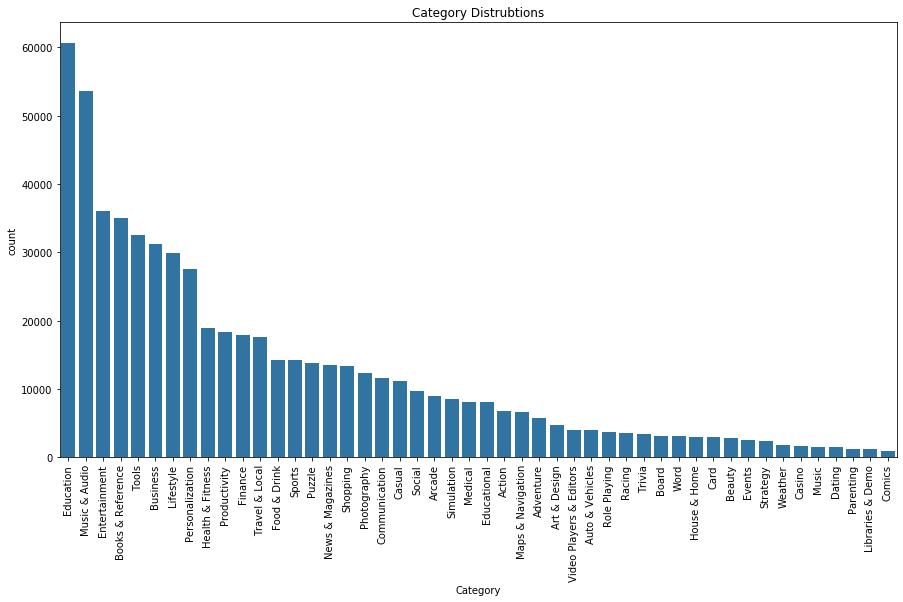

```python
# bar plot for Category distrubtions
bar_plot('Category Distrubtions', 'Category', (15, 8), rotation=90)
# print the top 5 value
df['Category'].value_counts()[:5]
```

> The Top 5 most common Category in Google play:  
> 1- Education  
> 2- Music & Audio  
> 3- Entertainment  
> 4- Books & Reference  
> 5- Tools

## What Apps Content Rating mostly common?

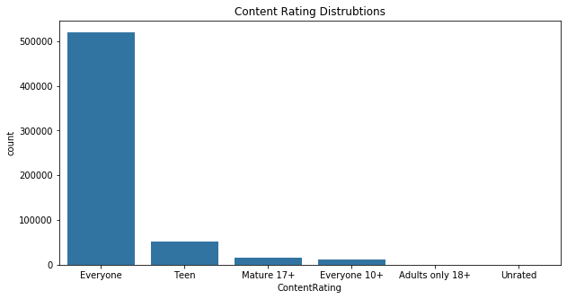

```python
# bar plot of the Content Rating distrubtions
bar_plot('Content Rating Distrubtions', 'ContentRating', (10, 5))
```

> most common content rating is Everyone.

## Free or paid mostly common?

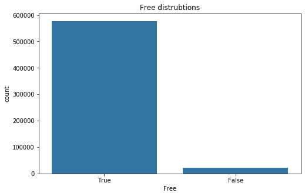

```python
# bar plot of the Free apps distrubtions
bar_plot('Free distrubtions', 'Free', (8, 5))
```

> Free apps is of course the most commmon in google play store.

## What is the shape of the rating distrubtions?

```
 Apps most rating : 0.6005895572483437
```

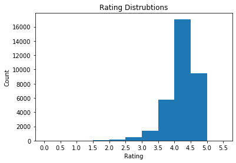

```python
# plot Rating distrubtions with hist plot
# NOTE: we use df_ now to explore Rating Distrubtions
hist_plot('Rating Distrubtions', 'Rating', 'Count', df_, 'Rating', 0.5)
# print the percentage of apps with rating between 4 and 4.5
print(" Apps most rating : " + str(df_.query(" Rating >= 4 and Rating <= 4.5").shape[0] / df_.shape[0]))
```

> the most of the apps have rating between 4 and 4.5

### Of the features you investigated, were there any unusual distributions? Did you perform any operations on the data to tidy, adjust, or change the form of the data? If so, why did you do this?

> Yes, In the data cleaning phase i convert Size, Installs varibals from string to float, remove nan value.

## Bivariate Exploration

> In this section, investigate relationships between pairs of variables in your data. Make sure the variables that you cover here have been introduced in some fashion in the previous section (univariate exploration).

## Which apps Category has the highest rating? (with rating count > 5000)

```
             Category    Rating
7   Books & Reference  4.488889
30          Parenting  4.479268
21   Health & Fitness  4.390859
47               Word  4.386463
10             Casino  4.384257
```

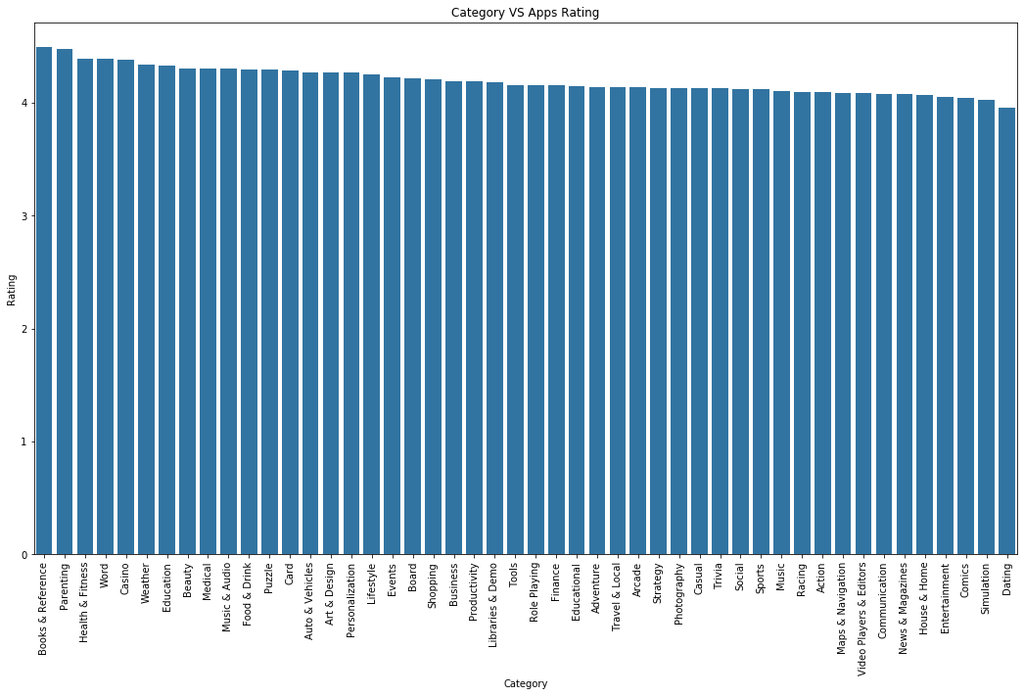

```python
# plot App Category VS App Rating
bar_plot2d('Category VS Apps Rating', df_, 'Category', 'Rating', rotation=90)
```

## Which apps Category has the most number of installs?

```
                   Category      Installs
35                   Racing  1.826021e+06
0                    Action  1.702627e+06
41                 Strategy  1.210556e+06
2                    Arcade  1.121770e+06
45  Video Players & Editors  1.003116e+06
```

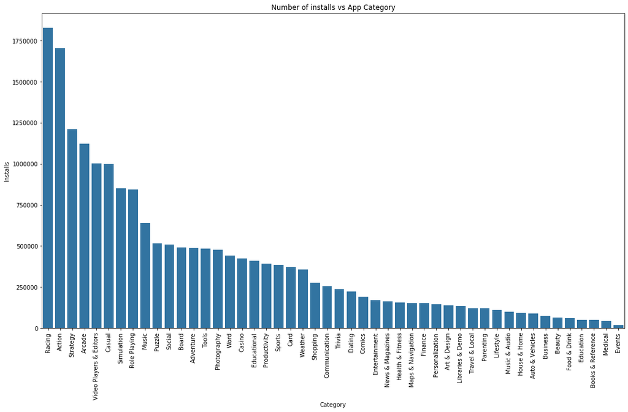

```python
# plot Number of installs vs App Category
bar_plot2d('Number of installs vs App Category', df, 'Category', 'Installs', rotation=90)
```

> The bar plot shows the relationship between app category and the number of installs of the app.  
> The top 5 apps category in number of installs:  
> 1- Racing.  
> 2- Action.  
> 3- Strategy.  
> 4- Arcade.  
> 5- Video Players & Editors.

## Which app Category has the largest size?

```
        Category       Size
36  Role Playing  52.334922
41      Strategy  49.237831
38    Simulation  48.237645
0         Action  46.711968
35        Racing  46.457667
```

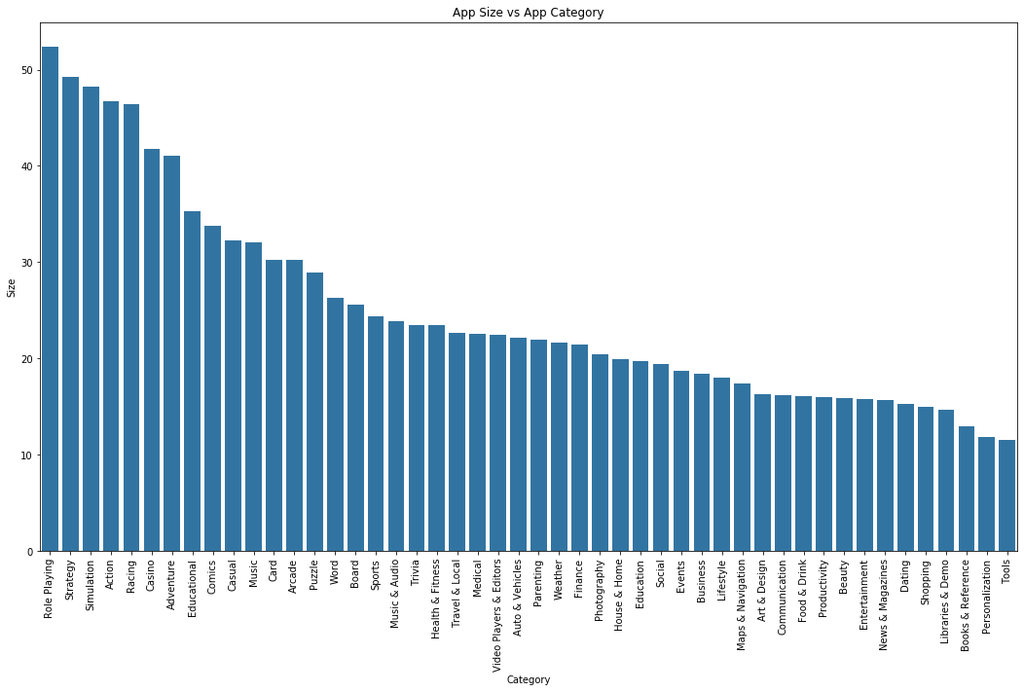

```python
bar_plot2d('App Size vs App Category', df, 'Category', 'Size', rotation=90)
```

> The bar plot shows the relationship between the app category and the size of the app.  
> The top 5 apps category in size:  
> 1- Role Playing.  
> 2- Strategy.  
> 3- Simulation.  
> 4- Action.  
> 5- Racing.

## Free or paid apps have a higher number of installs?

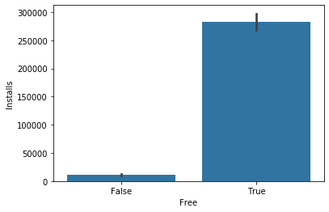

```python
# plot number of installs with free/paid apps
sb.barplot(data=df, x='Free', y='Installs', color=sb.color_palette()[0]);
```

> The free apps tend to have higher number of installs than paid apps, most people perfer free apps than paid apps.

## Free or paid apps have a higher rating?

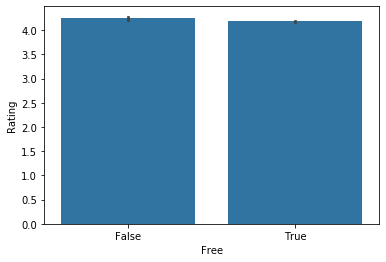

```python
# plot the rating of free/paid apps
sb.barplot(data=df_, x='Free', y='Rating', color=sb.color_palette()[0]);
```

> The paid apps tend to have higher rating than free apps, the paid apps mostly well designed apps so tend to have high rating.

## Is Editors Choice apps have higher rating?

```
   EditorsChoice    Rating
1           True  4.336735
0          False  4.176856
```

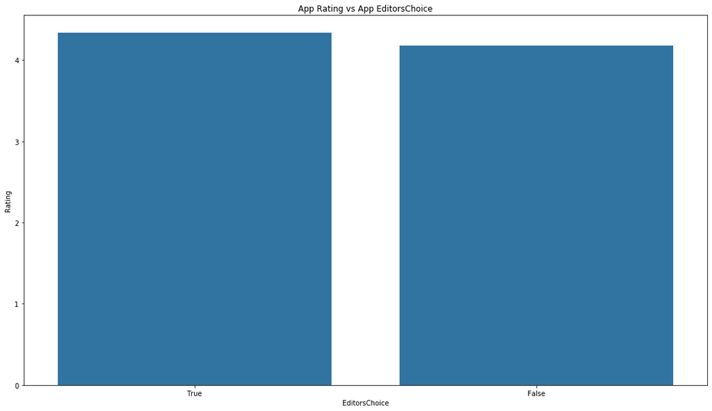

```python
bar_plot2d('App Rating vs App EditorsChoice', df_, 'EditorsChoice', 'Rating', rotation=0)
```

```python
# print the mean rating for EditorsChoice apps
print(df_.query("EditorsChoice == True")['Rating'].mean())
# print the mean rating for other apps
print(df_.query("EditorsChoice == False")['Rating'].mean())
```

```
4.336734693877551
4.176856244810817
```

> EditorsChoice app tend to be have higher rating than other apps, which totaly make sense.

## What is the relationship between a number of installs and rating?

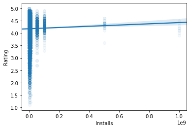

```python
# plot number of Installs VS the Rating of the app
sb.regplot(data = df_, x = 'Installs', y = 'Rating',  truncate=False, x_jitter=0.3, scatter_kws={'alpha':1/20});
```

```python
print(df_.query("Installs > " + str(df_['Installs'].mean()))['Rating'].mean())
print(df_.query("Installs < " + str(df_['Installs'].mean()))['Rating'].mean())
```

```
4.167379740980572
4.183419871169237
```

> look like there are very small relationship between number of installs and rating (very small corr).

### Talk about some of the relationships you observed in this part of the investigation. How did the feature(s) of interest vary with other features in the dataset?

> The bar plot above show the highest rating categories, The most installs app categories in play store, The relationship between app categories and size of the app.

## Multivariate Exploration

> Create plots of three or more variables to investigate your data even further. Make sure that your investigations are justified, and follow from your work in the previous sections.

## Rating VS Price for AdSupported Apps

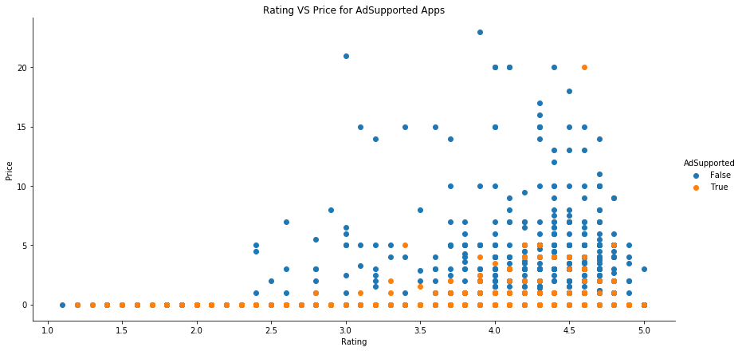

```python
# craete new data frame with only apps under 50$ and high rating count > 5000 from (df_)
df_1 = df_.query(" Price < 50 ")
# plot
g = sb.FacetGrid(data = df_1, hue = 'AdSupported', height = 6, aspect=2)
g.map(plt.scatter, 'Rating', 'Price')
# set title and legend
plt.title("Rating VS Price for AdSupported Apps")
g.add_legend();
```

> Paid apps have higher rating, but here we consider the Ads in the app, always apps without ads have better UX so tend to have higher rating. Apps with higher price tend to have no Ads.

## Category VS Rating for free/paid Apps

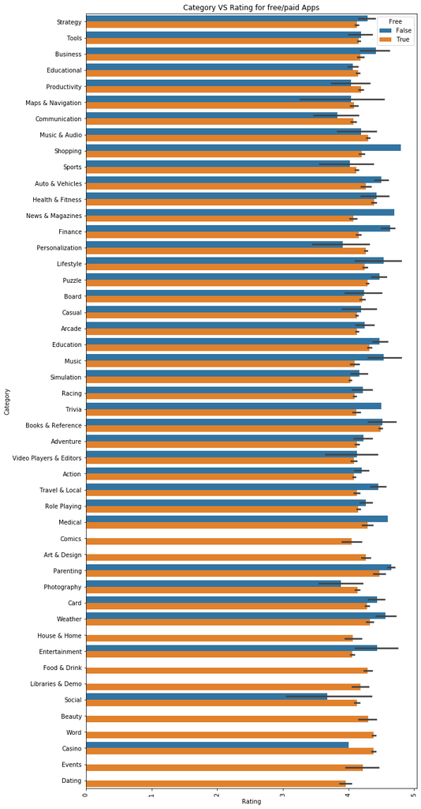

```python
# set fig Size
plt.figure(figsize=(10, 24))
# set fig title
plt.title("Category VS Rating for free/paid Apps")
# plt
sb.barplot(y="Category", x="Rating", hue="Free", data=df_);
# rotate ticks for better readability
plt.xticks(rotation=90);
```

> clearly paid apps in most Categories have high rating, explain: paid apps mostly have better UI and UX.

## Size VS Ads Supported withn In App Purchases Apps

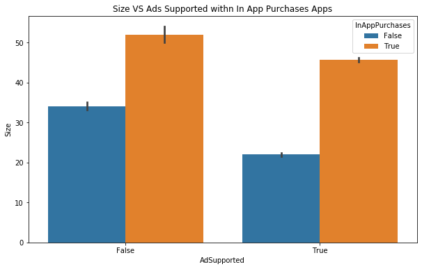

```python
# set fig Size
plt.figure(figsize=(10, 6))
# set fig title
plt.title("Size VS Ads Supported withn In App Purchases Apps")
# plot
sb.barplot(y="Size", x="AdSupported", hue="InAppPurchases", data=df_);
```

> Apps without Ads and In App Purchases tend to have higher size, because most of these apps is games.

## Heat map for all numaric features

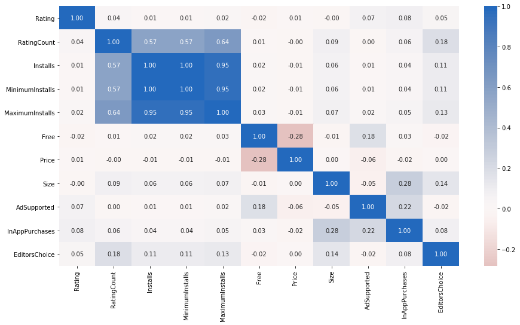

```python
# set fig Size
plt.figure(figsize=(15, 8))
# plot heat map
sb.heatmap(df_.corr(), annot = True, fmt = '.2f', cmap = 'vlag_r', center = 0);
```

### Talk about some of the relationships you observed in this part of the investigation. Were there features that strengthened each other in terms of looking at your feature(s) of interest?

> Small negative relation between price and apps with ads, most paid apps remove ads to have a better experience.  
> Small negative relation between free apps and rating and editors choice. Small positive relation between free apps and ads supported apps, most free apps make money from the ads in the included apps. large positive relation between rating counts and the number of installs.  
> small positive relation between editors choice and the number of installs, most people trust the editors choice apps because it has better quality.

> At the end of your report, make sure that you export the notebook as an html file from the `File > Download as... > HTML` menu. Make sure you keep track of where the exported file goes, so you can put it in the same folder as this notebook for project submission. Also, make sure you remove all of the quote-formatted guide notes like this one before you finish your report!